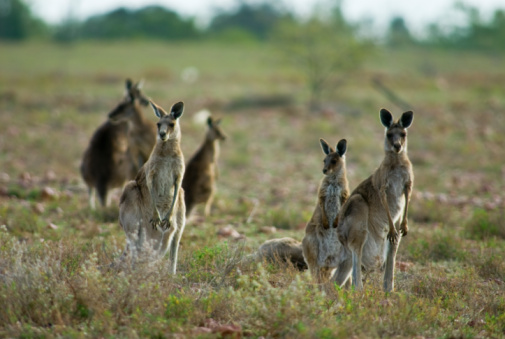

A team of environmental managers was concerned about the effects of increased soil salinity on native mammal populations in the arid zone of NSW. They conducted spotlight surveys for kangaroos at night at 10 sites, half of which were affected by soil salinity and half of which were unaffected by increased salinity. They obtained the following data:

Site Soil salinity Kangaroos (number per survey) 1 Saline 0 2 Saline 5 3 Saline 3 4 Saline 6 5 Saline 4 6 Natural 12 7 Natural 9 8 Natural 8 9 Natural 10 10 Natural 9

```r
kangaroo.sal = read.csv(file = "Kangaroos.csv", header = T)
```

Firstly, visualise the differences in kangaroo abundance between the two types of sites.

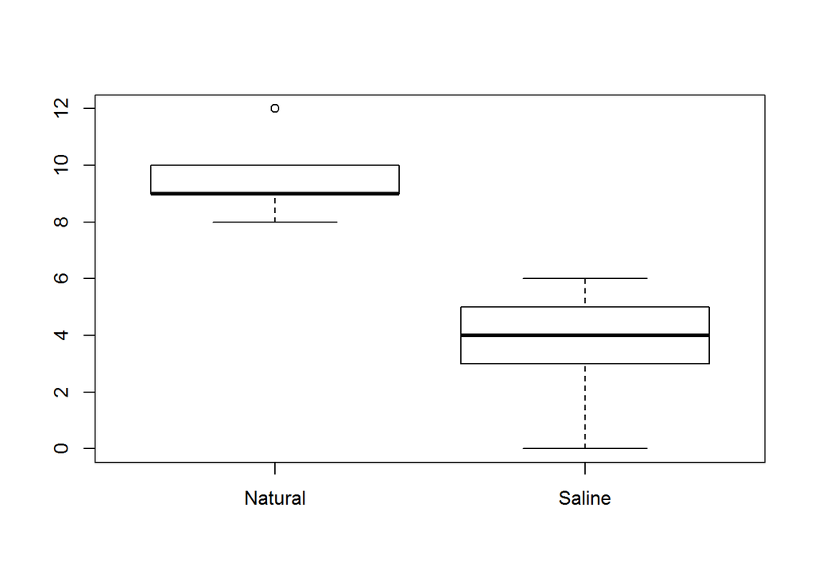

```r
boxplot(Kangaroos~Soil_salinity, data = kangaroo.sal)
```

**A)** What statistical test could you use to detect whether the abundance of kangaroos differed between areas affected and those unaffected by soil salinity?

```r
# {1:MULTICHOICE:=Two sample t test~Contingency table~Goodness of fit test~Paired t test}
```

**B)** After checking the assumptions of your test, conduct the test, and give the value of the test statistic and P value.

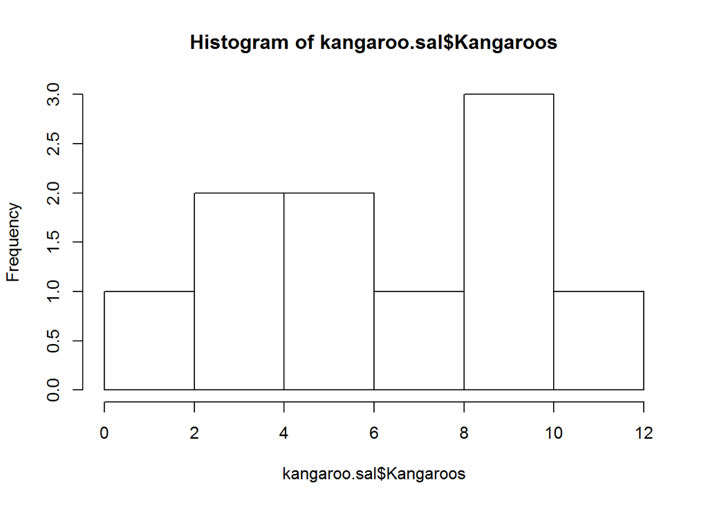

```r
hist(kangaroo.sal$Kangaroos)
```

```r
t.test(Kangaroos~Soil_salinity, data = kangaroo.sal)
```

```
##
##  Welch Two Sample t-test
##
## data:  Kangaroos by Soil_salinity
## t = 4.867, df = 6.922, p-value = 0.00188
## alternative hypothesis: true difference in means is not equal to 0
## 95 percent confidence interval:
##  3.078 8.922
## sample estimates:
## mean in group Natural  mean in group Saline
##                   9.6                   3.6
```

**C)** Is there any evidence that kangaroos are less abundant at the sites affected by excess salinity?

```r
# {1:MULTICHOICE:=Yes~No}
```

**D)** Write a paragraph that you could provide to the landholders that explains the results of the test